# VEREP Property Development Analysis

Strategic Assessment of Development Opportunities

Author

HDAdvisors

Published

November 13, 2025

# Executive Summary

**Key Findings**

This analysis evaluated **710** properties across the diocese to identify optimal development opportunities. Using a comprehensive scoring methodology, we identified **10 high-priority properties** representing **51.1 total acres** with significant development potential.

**Top Insights:** - **151** properties score in Tier 1-2 (strong development potential) - **Primary opportunities:** Underutilized parking lots and open space - **Average parcel size:** 5.21 acres - **Congregations with declining pledges:** 0 properties show high financial need

710

Properties Analyzed

10

High Priority Sites

51.1

Developable Acres

0

Financial Need

## At a Glance: Top 10 Properties

| Rank | Property Address | City | Acres | Score | Tier |
| --- | --- | --- | --- | --- | --- |
| 1 | 706 SAINT CHRISTOPHERS RD, RICHMOND 23226 | RICHMOND | 4.3 | 84.2 | Tier 1: High Priority |
| 2 | 1600 WESTBROOK AVE, RICHMOND 23227 | RICHMOND | 4.3 | 80.9 | Tier 1: High Priority |
| 3 | 600 NORTH MADISON ST, ARLINGTON 22203 | ARLINGTON | 2.0 | 80.0 | Tier 1: High Priority |
| 4 | WEST FALLS CHURCH 22042 | WEST FALLS CHURCH | 2.6 | 79.8 | Tier 1: High Priority |
| 5 | STERLING 20164 | STERLING | 2.5 | 79.5 | Tier 1: High Priority |
| 6 | CENTREVILLE 20120 | CENTREVILLE | 1.2 | 79.3 | Tier 1: High Priority |
| 7 | 1242 WEST QUEEN ST, HAMPTON 23669 | HAMPTON | 3.0 | 78.5 | Tier 1: High Priority |
| 8 | 710 ST CHRISTOPHERS RD, RICHMOND 23226 | RICHMOND | 0.6 | 78.2 | Tier 1: High Priority |
| 9 | 719 ST CHRISTOPHERS RD, RICHMOND 23226 | RICHMOND | 27.2 | 78.2 | Tier 1: High Priority |
| 10 | 5101 FILLMORE AVE, ALEXANDRIA 22311 | ALEXANDRIA | 3.4 | 76.6 | Tier 1: High Priority |

# Key Findings

## Significant Underutilized Assets

- **Parking lots** (highest development scores): Structured parking with mixed-use above
- **Open space parcels**: Well-located vacant land ideal for ground lease arrangements
- **Properties with declining congregations**: Sites where development can provide financial stability

## Geographic Distribution

Development opportunities are distributed across Virginia, with concentrations in: - Urban/suburban areas with strong walkability scores - Markets with favorable demographics and LIHTC eligibility - Transit-accessible locations supporting reduced parking requirements

## Financial Sustainability Imperative

**0 of the top 10 properties** are associated with congregations showing significant financial decline (pledge revenue down 20%+ over past decade). Strategic development can provide:

- Long-term ground lease revenue
- Capital for building improvements
- Sustainable financial model for congregation vitality

# Methodology & Data

## Background & Data Sources

### VEREP Parcel Dataset

This analysis utilizes the Virginia Episcopal Real Estate Portfolio (VEREP) parcel dataset, compiled by CGS Consultants. The dataset includes:

- **790 parcels** across Virginia
- Comprehensive property characteristics (size, use, zoning)
- Environmental constraints (floodplains, wetlands, easements)
- Location metrics (walkability, transit access)
- Market indicators (median income, demographics)

### Congregation Statistics (2014-2023)

Financial and membership data provides context on congregation health:

- Sunday attendance trends
- Membership changes
- Plate & pledge revenue
- 10-year trend analysis

**Data Quality Note**

Not all properties have associated congregation data. Properties without congregation information received neutral scores in the financial need category.

## Analytical Framework

### Development Potential Scoring

Our methodology evaluates six key dimensions:

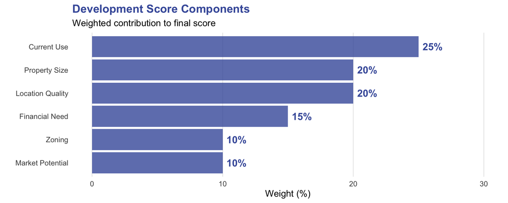

**Constraint Penalties:** Properties receive deductions for flood zones (-40), significant wetlands (-35), easements (-30), and historic district designation (-25).

### Development Tiers

Properties are classified into five tiers based on composite scores:

- **Tier 1 (75-100):** High Priority - Immediate development candidates
- **Tier 2 (60-74):** Strong Potential - Near-term opportunities
- **Tier 3 (45-59):** Moderate Potential - Requires creative solutions
- **Tier 4 (30-44):** Limited Potential - Significant barriers exist
- **Tier 5 (<30):** Not Recommended - Unsuitable for development

# Analysis Results

## Development Opportunity Landscape

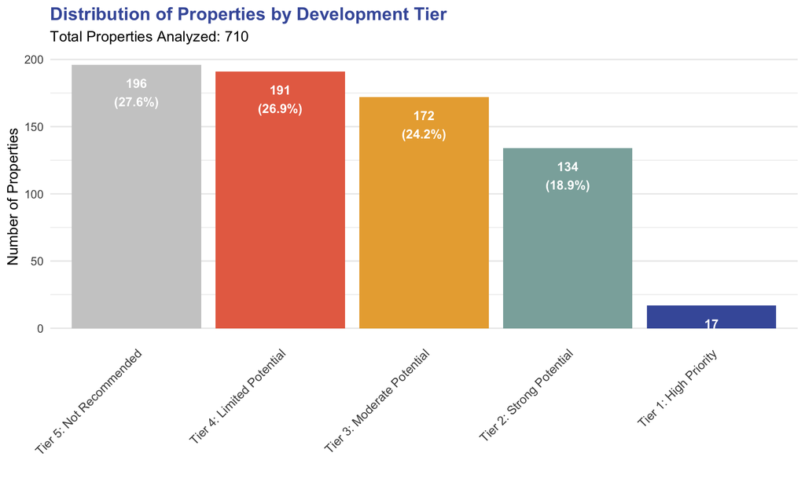

## Geographic Distribution

[interactive chart not shown]

# Summary Statistics

## Property Portfolio Overview

### Ownership Distribution

| Ownership Type | # Parcels | Total Acres | Assessed Value |
| --- | --- | --- | --- |
| Other | 710 | 3,697.2 | 1,686,339,307 |

### Property Use Types

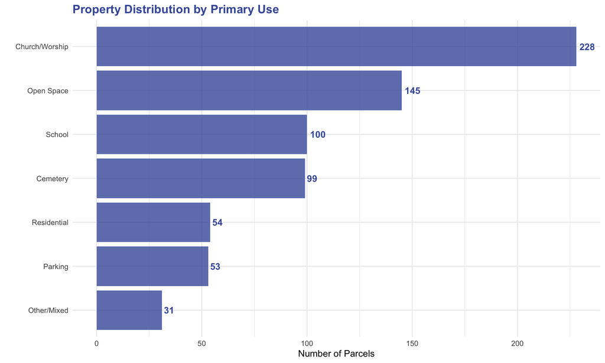

## Geographic Distribution

### Parcels by Diocesan Region

| Diocesan Region | # Parcels | Total Acres | % of Total Acreage | Avg Dev Score |
| --- | --- | --- | --- | --- |
| 3 | 99 | 242.8 | 6.6 | 52.4 |
| 12 | 80 | 387.8 | 10.5 | 46.0 |
| NA | 75 | 1146.6 | 31.0 | 37.2 |
| 9 | 74 | 470.3 | 12.7 | 33.1 |
| 4 | 53 | 213.9 | 5.8 | 41.5 |
| 8 | 45 | 106.1 | 2.9 | 32.0 |
| 6 | 37 | 176.3 | 4.8 | 33.0 |
| 16 | 37 | 103.3 | 2.8 | 33.4 |
| 14 | 33 | 82.3 | 2.2 | 59.8 |
| 5 | 30 | 66.8 | 1.8 | 35.1 |
| 1 | 29 | 117.1 | 3.2 | 53.6 |
| 11 | 24 | 178.3 | 4.8 | 46.8 |
| 0 | 20 | 25.9 | 0.7 | 38.1 |
| 2 | 19 | 15.4 | 0.4 | 45.9 |
| 13 | 19 | 125.0 | 3.4 | 54.8 |
| 10 | 13 | 63.4 | 1.7 | 60.0 |
| 15 | 12 | 159.1 | 4.3 | 49.7 |
| 7 | 11 | 16.7 | 0.5 | 38.0 |

## Building and Asset Statistics

1,075

Total Buildings

87

Avg Building Age (years)

$1,686.3M

Total Assessed Value

## Congregation Vitality Metrics

```
**Key Congregation Metrics:**
```

```
- **Parcels with congregation data:** 0
```

[output not shown]

[output not shown]

[output not shown]

```
- **Congregations with declining pledges:** 0
```

## Developable Land Summary

### Comprehensive Developability Analysis

### All Developable Properties (Score ≥45)

323

Developable Parcels

1457.8

Developable Acres

$1,298.1M

Assessed Value

0

With <30 Attendance

### Breakdown by Development Tier

| Tier | # Parcels | Total Acres | Assessed Value |
| --- | --- | --- | --- |
| Tier 3: Moderate Potential | 172 | 796.8 | 257,259,436 |
| Tier 2: Strong Potential | 134 | 588.3 | 917,233,505 |
| Tier 1: High Priority | 17 | 72.6 | 123,595,982 |

# Property Profiles

## Overview

The following section provides detailed profiles for each of the top 10 development opportunities. Each profile includes:

- Site characteristics and current use
- Congregation context (where applicable)
- Development opportunities and strategies
- Key considerations and next steps

## Property #1

### 706 SAINT CHRISTOPHERS RD, RICHMOND 23226

**RICHMOND, RICHMOND-CITY County**

**Development Score: **84.2/100**

**Tier 1: High Priority**

**4.3 acres**  
Property Size

**18.3/100**  
Walkability

**N/A**  
Avg Attendance

#### Site Characteristics

- **Current Uses:** Parking lot #### Development Opportunities

🅿️ **Prime opportunity:** Underutilized parking can support structured parking with mixed-use above

📐 **Substantial site:** Large parcel enables phased development or creative master planning

#### Recommended Next Steps

1. Site feasibility study and geotechnical analysis
2. Congregation leadership engagement
3. Zoning review and density bonus evaluation

## Property #2

### 1600 WESTBROOK AVE, RICHMOND 23227

**RICHMOND, RICHMOND-CITY County**

**Development Score: **80.9/100**

**Tier 1: High Priority**

**4.31 acres**  
Property Size

**12.8/100**  
Walkability

**N/A**  
Avg Attendance

#### Site Characteristics

- **Current Uses:** Parking lot, Open space #### Development Opportunities

🅿️ **Prime opportunity:** Underutilized parking can support structured parking with mixed-use above

📐 **Substantial site:** Large parcel enables phased development or creative master planning

#### Recommended Next Steps

1. Site feasibility study and geotechnical analysis
2. Congregation leadership engagement
3. Zoning review and density bonus evaluation

## Property #3

### 600 NORTH MADISON ST, ARLINGTON 22203

**ARLINGTON, FAIRFAX County**

**Development Score: **80/100**

**Tier 1: High Priority**

**1.96 acres**  
Property Size

**17/100**  
Walkability

**N/A**  
Avg Attendance

#### Site Characteristics

- **Current Uses:** Parking lot #### Development Opportunities

🅿️ **Prime opportunity:** Underutilized parking can support structured parking with mixed-use above

📐 **Substantial site:** Large parcel enables phased development or creative master planning

#### Recommended Next Steps

1. Site feasibility study and geotechnical analysis
2. Congregation leadership engagement
3. Zoning review and density bonus evaluation

## Property #4

### WEST FALLS CHURCH 22042

**WEST FALLS CHURCH, FAIRFAX County**

**Development Score: **79.8/100**

**Tier 1: High Priority**

**2.62 acres**  
Property Size

**13/100**  
Walkability

**N/A**  
Avg Attendance

#### Site Characteristics

- **Current Uses:** Church building, Open space #### Development Opportunities

📐 **Substantial site:** Large parcel enables phased development or creative master planning

#### Recommended Next Steps

1. Site feasibility study and geotechnical analysis
2. Congregation leadership engagement
3. Zoning review and density bonus evaluation

## Property #5

### STERLING 20164

**STERLING, FAIRFAX County**

**Development Score: **79.5/100**

**Tier 1: High Priority**

**2.48 acres**  
Property Size

**12.5/100**  
Walkability

**N/A**  
Avg Attendance

#### Site Characteristics

- **Current Uses:** Open space #### Development Opportunities

📐 **Substantial site:** Large parcel enables phased development or creative master planning

#### Recommended Next Steps

1. Site feasibility study and geotechnical analysis
2. Congregation leadership engagement
3. Zoning review and density bonus evaluation

## Property #6

### CENTREVILLE 20120

**CENTREVILLE, FAIRFAX County**

**Development Score: **79.3/100**

**Tier 1: High Priority**

**1.24 acres**  
Property Size

**15.5/100**  
Walkability

**N/A**  
Avg Attendance

#### Site Characteristics

- **Current Uses:** Open space #### Development Opportunities

#### Recommended Next Steps

1. Site feasibility study and geotechnical analysis
2. Congregation leadership engagement
3. Zoning review and density bonus evaluation

## Property #7

### 1242 WEST QUEEN ST, HAMPTON 23669

**HAMPTON, HAMPTON County**

**Development Score: **78.5/100**

**Tier 1: High Priority**

**3.05 acres**  
Property Size

**11.2/100**  
Walkability

**N/A**  
Avg Attendance

#### Site Characteristics

- **Current Uses:** Church building, Parking lot, Open space #### Development Opportunities

🅿️ **Prime opportunity:** Underutilized parking can support structured parking with mixed-use above

📐 **Substantial site:** Large parcel enables phased development or creative master planning

#### Recommended Next Steps

1. Site feasibility study and geotechnical analysis
2. Congregation leadership engagement
3. Zoning review and density bonus evaluation

## Property #8

### 710 ST CHRISTOPHERS RD, RICHMOND 23226

**RICHMOND, RICHMOND-CITY County**

**Development Score: **78.2/100**

**Tier 1: High Priority**

**0.61 acres**  
Property Size

**18.3/100**  
Walkability

**N/A**  
Avg Attendance

#### Site Characteristics

- **Current Uses:** Parking lot #### Development Opportunities

🅿️ **Prime opportunity:** Underutilized parking can support structured parking with mixed-use above

#### Recommended Next Steps

1. Site feasibility study and geotechnical analysis
2. Congregation leadership engagement
3. Zoning review and density bonus evaluation

## Property #9

### 719 ST CHRISTOPHERS RD, RICHMOND 23226

**RICHMOND, RICHMOND-CITY County**

**Development Score: **78.2/100**

**Tier 1: High Priority**

**27.18 acres**  
Property Size

**18.3/100**  
Walkability

**N/A**  
Avg Attendance

#### Site Characteristics

- **Current Uses:** Parking lot, Open space #### Development Opportunities

🅿️ **Prime opportunity:** Underutilized parking can support structured parking with mixed-use above

📐 **Substantial site:** Large parcel enables phased development or creative master planning

#### Recommended Next Steps

1. Site feasibility study and geotechnical analysis
2. Congregation leadership engagement
3. Zoning review and density bonus evaluation

## Property #10

### 5101 FILLMORE AVE, ALEXANDRIA 22311

**ALEXANDRIA, ALEXANDRIA County**

**Development Score: **76.6/100**

**Tier 1: High Priority**

**3.37 acres**  
Property Size

**12.3/100**  
Walkability

**N/A**  
Avg Attendance

#### Site Characteristics

- **Current Uses:** Parking lot, Open space #### Development Opportunities

🅿️ **Prime opportunity:** Underutilized parking can support structured parking with mixed-use above

📐 **Substantial site:** Large parcel enables phased development or creative master planning

#### Recommended Next Steps

1. Site feasibility study and geotechnical analysis
2. Congregation leadership engagement
3. Zoning review and density bonus evaluation

# Appendices

**Technical Methodology**

**Scoring Algorithm Details**

Each property receives scores across six dimensions (0-100 scale), which are then weighted and combined:

1. **Size Score (20% weight):** Properties between 0.5-5 acres score highest (100 points)
2. **Use Score (25% weight):** Parking lots (95) and open space (90) score highest
3. **Location Score (20% weight):** Based on walkability index and transit access
4. **Financial Score (15% weight):** Congregation pledge trends indicate development need
5. **Market Score (10% weight):** Area median income and LIHTC eligibility
6. **Zoning Score (10% weight):** Development-friendly zoning receives 80 points

**Constraint penalties** are applied after the weighted average, with major penalties for: - Flood zones: -40 points - Significant wetlands (>25%): -35 points  
- Easements: -30 points - Historic districts: -25 points

Final scores are capped between 0-100.

**Data Processing Notes**

**Congregation-Parcel Joining:** Properties were matched to congregation data using the `congr_name` field. Properties without matches received neutral financial scores.

**Missing Data Handling:** - Missing walkability scores defaulted to 0 - Missing income data received median market scores (50) - Properties without area or coordinates were excluded

**Quality Filters:** - Minimum parcel size: 0.1 acres - Required valid lat/lon coordinates - Valid building years: 1700-2025